# Week 1: Visualising data using R

# Getting started

This week we will demonstrate various techniques for visualising data in R using `ggplot2`. This will also include the correct interpretation and understanding of the different plotting techniques.

## Load libraries

We shall now load into R all of the libraries we will need for this session. This can be done by typing the following into your R script:

```r
library(ggplot2)
library(nycflights13)
```

1. The first library `ggplot2` allows us to use functions within that package in order to create nicer data visualisations.
2. The second library `nycflights13` contains data on flights from New York City in 2013 that we shall be examining.

## Viewing the data

Before visualising any data set, we first need to know its contents. For example, the contents of the `flights` data within the `nycflights13` library can be observed using the following command:

```r
head(flights, n = 3)
```

```
# A tibble: 3 × 19
   year month   day dep_time sched_dep_time dep_delay arr_time sched_arr_time
  <int> <int> <int>    <int>          <int>     <dbl>    <int>          <int>
1  2013     1     1      517            515         2      830            819
2  2013     1     1      533            529         4      850            830
3  2013     1     1      542            540         2      923            850
# ℹ 11 more variables: arr_delay <dbl>, carrier <chr>, flight <int>,
#   tailnum <chr>, origin <chr>, dest <chr>, air_time <dbl>, distance <dbl>,
#   hour <dbl>, minute <dbl>, time_hour <dttm>
```

To reduce the amount of data we will be working with and make things a little easier, let’s only look at *Alaska Airlines* flights leaving from New York City in 2013.

```r
Alaska <- flights[flights$carrier == "AS", ]
```

## Scatterplots

```r
ggplot(data = Alaska,
       mapping = aes(x = dep_delay, y = arr_delay)) +
  geom_point() +
  labs(x = "Departure delay (minutes)", y = "Arrival delay (minutes)",
       title = "Alaska Airlines flights leaving NYC in 2013")
```

A layer combines data, aesthetic mapping, a geom (geometric object), a stat (statistical transformation), and a position adjustment.

```r
ggplot(data,aes(x,y)) +
  layer(
  mapping = NULL,
  data = NULL,
  geom = "point", geom_params = list(),
  stat = "identity", stat_params = list(),
  position = "identity"
)
```

## Scatterplots

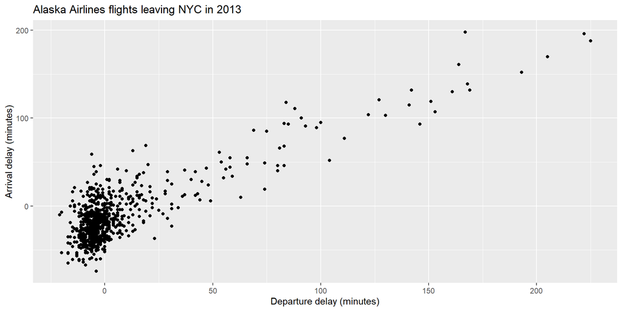

## Histograms

Histograms allow us to look at the *statistical distribution* of a variable. They show us how many values of a variable fall within specified *bins*.

Here, let’s take a look at the `weather` data set that is within the `nycflights13` library. This data set contains hourly weather data from three airports (LGA, JFK and EWR) in New York City in 2013.

```r
head(weather, n = 3)
```

```
# A tibble: 3 × 15
  origin  year month   day  hour  temp  dewp humid wind_dir wind_speed wind_gust
  <chr>  <int> <int> <int> <int> <dbl> <dbl> <dbl>    <dbl>      <dbl>     <dbl>
1 EWR     2013     1     1     1  39.0  26.1  59.4      270      10.4         NA
2 EWR     2013     1     1     2  39.0  27.0  61.6      250       8.06        NA
3 EWR     2013     1     1     3  39.0  28.0  64.4      240      11.5         NA
# ℹ 4 more variables: precip <dbl>, pressure <dbl>, visib <dbl>,
#   time_hour <dttm>
```

## Histograms

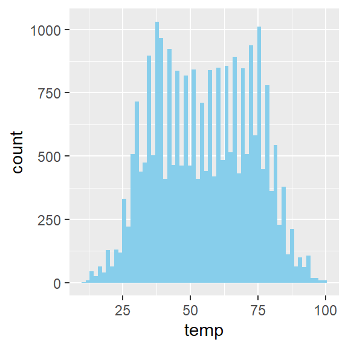

```r
ggplot(data = weather, aes(x = temp)) +
  geom_histogram(bins = 60,
                 fill = "skyblue")
```

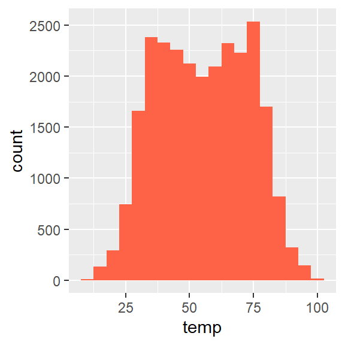

```r
ggplot(data = weather, aes(x = temp)) +
  geom_histogram(binwidth =  5,
                 fill = "tomato")
```

## Boxplots

```r
boxplot(weather$temp, ylab = "Hourly Temperature",
        main = "Hourly temperatures from NYC in 2013")
text(x= 1.35, y= summary(weather$temp)[1], labels= "Q1 - 1.5*IQR")
text(x= 1.35, y= summary(weather$temp)[2], labels= "Q1")
text(x= 1.35, y= summary(weather$temp)[3], labels= "Median")
text(x= 1.35, y= summary(weather$temp)[5], labels= "Q3")
text(x= 1.35, y= summary(weather$temp)[6], labels= "Q3 + 1.5*IQR")
```

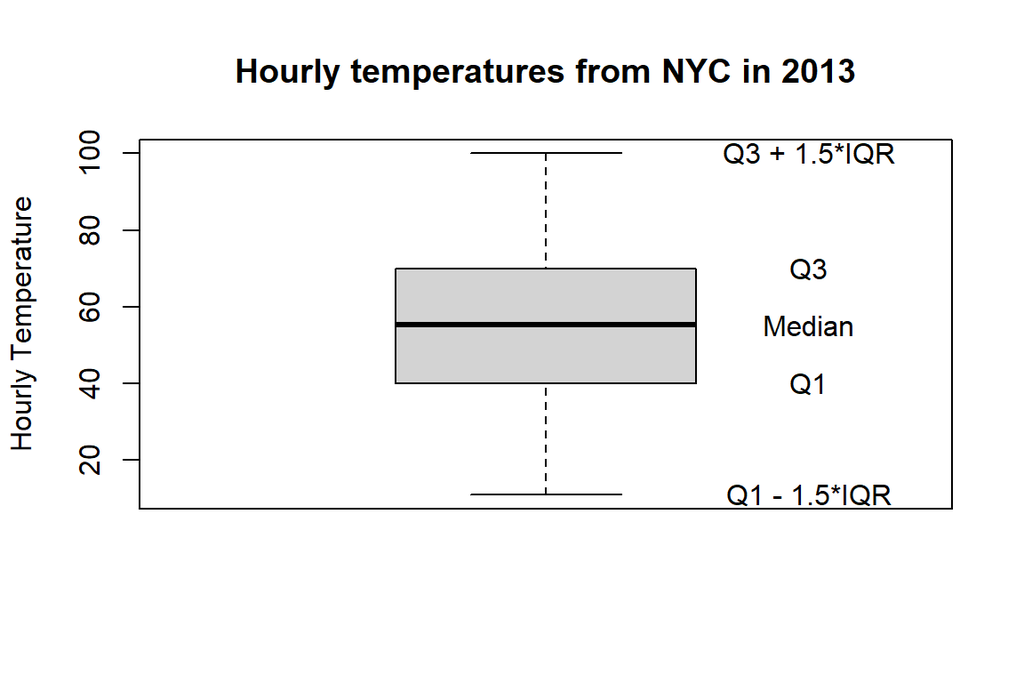

- the *interquartile range (IQR)*, that is, the height of the box (3rd - 1st quartiles)

## Boxplots

```r
ggplot(data = weather, aes(x = factor(month), y = temp)) +
  geom_boxplot(fill = "steelblue") +
  labs(x = "Month", y = "Temperature (Hourly)",
        title = "Hourly temperatures from NYC in 2013 by month")  +
  scale_x_discrete(labels = c("Jan", "Feb", "Mar", "Apr", "May", "Jun",
                              "Jul", "Aug", "Sep", "Oct", "Nov", "Dec"))
```

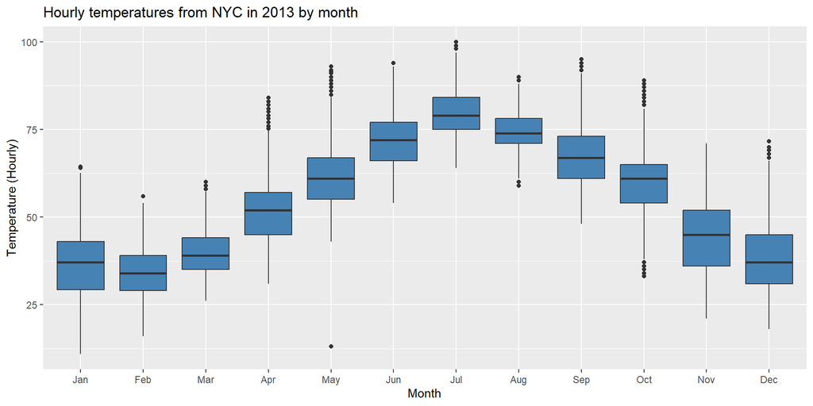

## Barplots

Barplots, or barcharts, are used to visualise the distributions of categorical variables.

```r
carrier.freq <- table(flights$carrier)
carrier.freq <- as.data.frame(carrier.freq)
colnames(carrier.freq) <- c("carrier", "number")
head(carrier.freq,n=6)
```

```
  carrier number
1      9E  18460
2      AA  32729
3      AS    714
4      B6  54635
5      DL  48110
6      EV  54173
```

## Barplots

You can use two types of data sets to create barplots:

1. data with variable(s) representing the categories

   ```r
   ggplot(flights, aes(y = carrier)) +
     geom_bar()
   ```

`geom_bar()` by default counts the number of cases for each level of a categorical variable.

2. variables representing the categories and the counts of each category

```r
ggplot(data = carrier.freq, aes(x = carrier, y = number)) +
  geom_col()
```

`geom_col()` expects a data set that already contains the count for each group

## Barplots for two categorical variables

Example: Number of flights that flew out of New York City in 2013 from each carrier and from each airport (LGA, JFK and EWR).

```r
ggplot(data = flights,
       aes(y = carrier,fill=origin)) +
  geom_bar()+
  coord_flip()
```

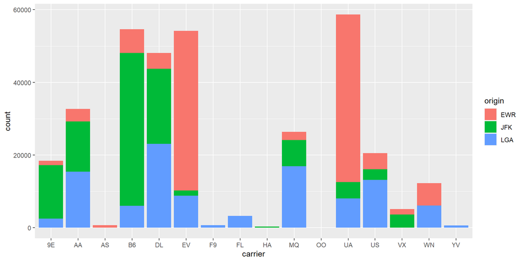

## Barplots: stacked vs side-by-side

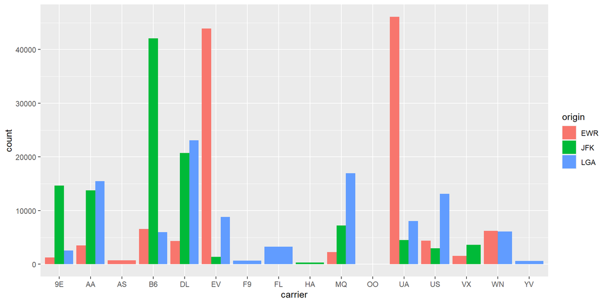

```r
ggplot(data = flights,
       aes(y = carrier,fill=origin)) +
  geom_bar(position = 'dodge')+
  coord_flip()
```

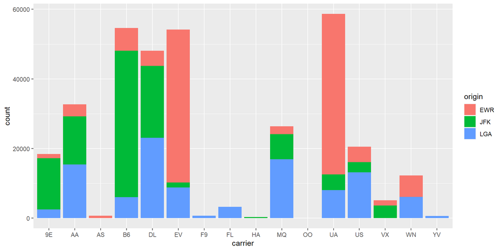

```r
ggplot(data = flights,
       aes(y = carrier,fill=origin)) +
  geom_bar()+
  coord_flip()
```

- What could be considered a positive of using a side-by-side barplot as opposed to a stacked barplot?

## Using Facets

Easier way to compare the carrier distributions by origin with the `facet_wrap` function.

```r
ggplot(data = flights,
       aes(y = carrier,fill=origin)) +
  geom_bar()+
  coord_flip()+
  facet_wrap(~ origin, ncol = 1,scales = "free_x")
```

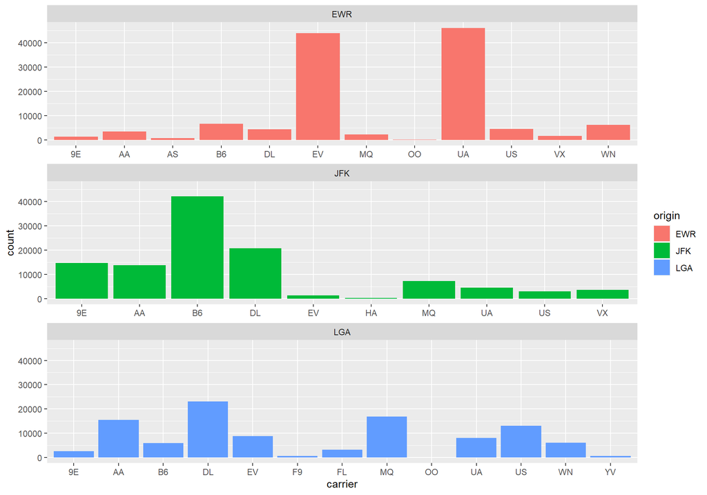

- What is the reason for the `scales = "free_x"` argument?
- What is the difference between histograms and barplots?
- Why can’t we use histograms to visualise categorical variables?

## Percentage/proportion barcharts

Instead of plotting the raw frequencies, we can plot the proportions or the percentages per category.

By default, `ggplot` maps at the beginning, using the layer data provided by the user. Alternatively, we can tell `ggplot` to map after a layer `stat()` has applied a defined statistical transformation using the `after_stat` function.

We will load the `ggstats` library which adds new statistics, geometries and positions to ggplot objects.

```r
library(ggstats)
ggplot(data = flights,
  aes(x = carrier,
      y = after_stat(prop),
      fill = origin)) +
  geom_bar(stat = "prop")
```

These are the proportions out of the total flights. What if we want the percentages per carrier?

## Percentage/proportion barcharts

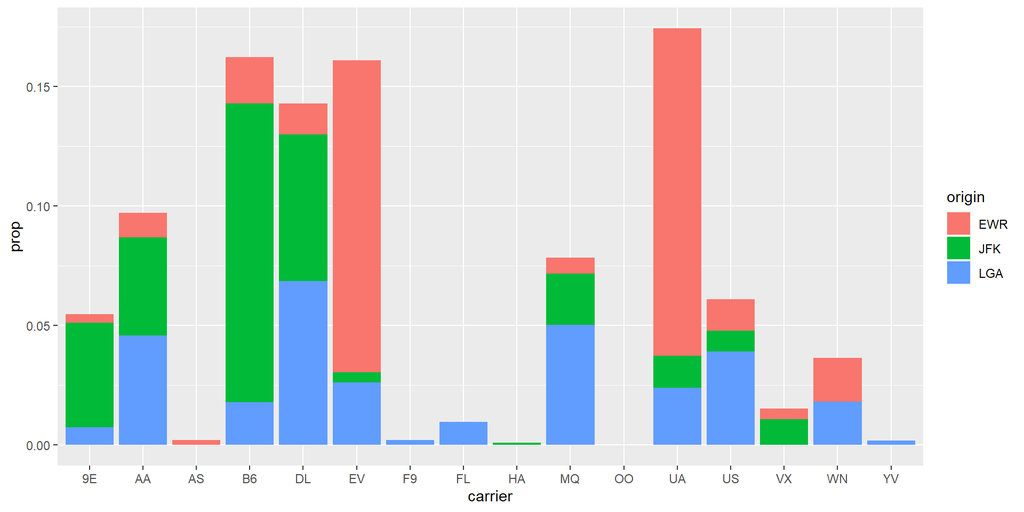

## Percentage/proportion barcharts

```r
ggplot(data = flights,
  aes(x = carrier,
      y = after_stat(prop),
      fill = origin,
      by=factor(carrier))) +
  geom_bar(stat = "prop")+
  geom_text(stat = "prop",
            position = position_fill(vjust=0.5))
```

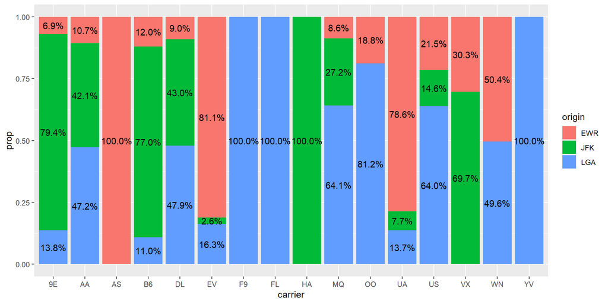

## Linegraphs

To produce linegraphs using `ggplot` we use the `geom_line` function. Here we are going to use hourly temperature data for Newark International Airport in January only.

```r
Newark.Jan <- weather[weather$origin == "EWR" & weather$month == 1, ]
ggplot(data = Newark.Jan, mapping = aes(x = time_hour, y = temp)) +
  geom_line() +
    labs(x = "Time (Hours)", y = "Temperature",
        title = "Hourly Temperature at Newark Airport in January 2013")
```

- In the code for the linegraph above, why has `time_hour` been plotted on the x-axis and not `hour`?
- Why should linegraphs be avoided when there is no sequential ordering of the data?

## Linegraphs

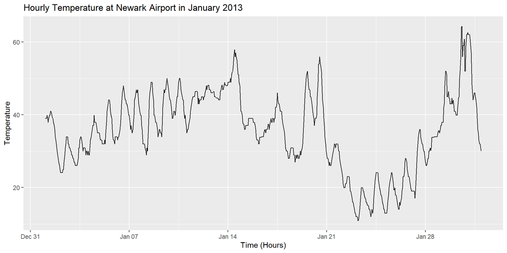

## Tasks

1. From the `flights` data set, subset the data for the airline carrier `JetBlue Airways` and produce a scatterplot of their departure delays against arrival delays using `ggplot`. Interpret the scatterplot.
2. Produce a histogram of the hourly temperature from Newark Liberty International (EWR) Airport in 2013 using `ggplot`. How does the temperature distribution compare with that from all airports in New York City in 2013?
3. For John F. Kennedy Airport, produce boxplots (using a single `ggplot` command) of the hourly temperature for the months May, June, July, August and September. How does the hourly temperature change during this period?
4. Take a look at the `mtcars` data set within the `datasets` library relating to data extracted from the 1974 *Motor Trend* US magazine. Using `ggplot`, produce a faceted barplot of the categorical variables relating to the number of cylinders (`cyl`) and the automobiles transmission (`am`). Interpret the barplot.
5. Produce a linegraph of the hourly temperature at LAGuardia (LGA) Airport for the month of October 2013. Interpret the linegraph.